# Review of vectors and matrices, for loops, random sampling, and ggplot

Advanced Ecology: Populations and Communities

10/14/2021

## Overview

This script gives examples of:

1. Vector and Matrix operations in R
2. `for` loops
3. Random sampling in R
4. Figures with `ggplot2`

## Vector and matrix operations in R

Vectors are one the primary data structures in R and can be made in different ways depending on the type of data stored. Math can be done on numeric vectors.

```r
# make a numeric vector
a = c(1.1,5,3,4)
a
```

```
## [1] 1.1 5.0 3.0 4.0
```

```r
# make a integer vector
b = 1:15
b
```

```
##  [1]  1  2  3  4  5  6  7  8  9 10 11 12 13 14 15
```

```r
# make a character vector
c = c('a', 'b', 'c')
c
```

```
## [1] "a" "b" "c"
```

```r
# summary statistics of sequence of numbers
d = rnorm(n = 40, mean = 6, sd = 2)
mean(d) #mean
```

```
## [1] 6.544058
```

```r
median(d) #median
```

```
## [1] 6.410377
```

```r
sd(d) #standard deviation
```

```
## [1] 1.933572
```

```r
quantile(d, c(0.025, 0.975)) # 95% CI
```

```
##     2.5%    97.5%
## 3.760787 9.975000
```

```r
# math with vectors
e = c(3, 1, 5, 6)
e*4
```

```
## [1] 12  4 20 24
```

```r
e*e
```

```
## [1]  9  1 25 36
```

Another data structure that is useful in ecological uses of R are matrices. A matrix is made with the `matrix()` function with the basic syntax `matrix(data = , nrow = , ncol = , byrow = , dimnames = )`.

`data =` the input vector which becomes the data elements of the matrix.

`nrow =` the number of rows to be created.

`ncol =` the number of columns to be created.

`byrow = FALSE` if `TRUE` then the input vector elements are arranged by row.

`dimname =` the names assigned to the rows and columns.

```r
# make a matrix using nrow
m1 = matrix(c(1,2,3,4,5,6), nrow = 2)
m1
```

```
##      [,1] [,2] [,3]
## [1,]    1    3    5
## [2,]    2    4    6
```

```r
# make a matrix using ncol
m2 = matrix(c(1,2,3,4,5,6), ncol = 2)
m2
```

```
##      [,1] [,2]
## [1,]    1    4
## [2,]    2    5
## [3,]    3    6
```

```r
# make a matrix using nrow and by row
m3 = matrix(c(1,2,3,4,5,6), ncol = 2, byrow = T)
m3
```

```
##      [,1] [,2]
## [1,]    1    2
## [2,]    3    4
## [3,]    5    6
```

Matrices can be indexed in 2 ways

```r
# make a matrix using ncol
m2 = matrix(c(1,2,3,4,5,6), ncol = 2)
m2
```

```
##      [,1] [,2]
## [1,]    1    4
## [2,]    2    5
## [3,]    3    6
```

```r
m2[1,2]
```

```
## [1] 4
```

```r
m2[4]
```

```
## [1] 4
```

```r
# make a matrix using nrow and by row
m3 = matrix(c(1,2,3,4,5,6), ncol = 2, byrow = T)
m3
```

```
##      [,1] [,2]
## [1,]    1    2
## [2,]    3    4
## [3,]    5    6
```

```r
m3[1,2]
```

```
## [1] 2
```

```r
m3[4]
```

```
## [1] 2
```

Matrix algebra can be done on matrices. There are specific matrix opperation like `%*%`, and functions like `sum()`,`mean()`, `rowSums()`, `colSums()`, `rowMeans()`, and `colMeans()` can be used to sum up entire matrices or specific rows or columns.

```r
m2 = matrix(c(1,2,3,4,5,6), ncol = 3)
m2
```

```
##      [,1] [,2] [,3]
## [1,]    1    3    5
## [2,]    2    4    6
```

```r
m2 + 1
```

```
##      [,1] [,2] [,3]
## [1,]    2    4    6
## [2,]    3    5    7
```

```r
m2/3
```

```
##           [,1]     [,2]     [,3]
## [1,] 0.3333333 1.000000 1.666667
## [2,] 0.6666667 1.333333 2.000000
```

```r
m3 = matrix(c(1,2,3,4,5,6), ncol = 3, byrow = T)
m3
```

```
##      [,1] [,2] [,3]
## [1,]    1    2    3
## [2,]    4    5    6
```

```r
m2 + m3
```

```
##      [,1] [,2] [,3]
## [1,]    2    5    8
## [2,]    6    9   12
```

```r
m3 - m2
```

```
##      [,1] [,2] [,3]
## [1,]    0   -1   -2
## [2,]    2    1    0
```

```r
# multply matrix with vector
v = c(1,2,3)

m2*v
```

```
##      [,1] [,2] [,3]
## [1,]    1    9   10
## [2,]    4    4   18
```

```r
# matrix multiplication
m4 = matrix(c(1,2,3), ncol = 1)
m2 %*% m4
```

```
##      [,1]
## [1,]   22
## [2,]   28
```

```r
# functions with matrices
m2
```

```
##      [,1] [,2] [,3]
## [1,]    1    3    5
## [2,]    2    4    6
```

```r
sum(m2)
```

```
## [1] 21
```

```r
mean(m2)
```

```
## [1] 3.5
```

```r
rowSums(m2)
```

```
## [1]  9 12
```

```r
rowMeans(m2)
```

```
## [1] 3 4
```

```r
colSums(m2)
```

```
## [1]  3  7 11
```

```r
colMeans(m2)
```

```
## [1] 1.5 3.5 5.5
```

## `for` loops

Another useful tool in programming is `for` loops. `for` loops repeat a process for a certain number of iterations. These can be useful iterate over a dataset or when using information in a time series. The `for` loop works over the number sequence indicated and does the code within the loop (inside of `{}`) for each number in the sequence. The iteration is typically indicated with `i`, but is just an object that is replaced at the begining of each loop and can be anything.

```r
for(i in 1:10){
  print(i)
}
```

```
## [1] 1
## [1] 2
## [1] 3
## [1] 4
## [1] 5
## [1] 6
## [1] 7
## [1] 8
## [1] 9
## [1] 10
```

```r
for(turtle in 5:10){
  print(turtle)
}
```

```
## [1] 5
## [1] 6
## [1] 7
## [1] 8
## [1] 9
## [1] 10
```

```r
for(flower in 1:nrow(iris)){
  cat('The species for this iteration is ',
      as.character(iris$Species[flower]), '\n')
}
## The species for this iteration is  setosa
## The species for this iteration is  setosa
## The species for this iteration is  setosa
## The species for this iteration is  setosa
## The species for this iteration is  setosa
## The species for this iteration is  setosa
## The species for this iteration is  setosa
## The species for this iteration is  setosa
## The species for this iteration is  setosa
## The species for this iteration is  setosa
## The species for this iteration is  setosa
## The species for this iteration is  setosa
## The species for this iteration is  setosa
## The species for this iteration is  setosa
## The species for this iteration is  setosa
## The species for this iteration is  setosa
## The species for this iteration is  setosa
## The species for this iteration is  setosa
## The species for this iteration is  setosa
## The species for this iteration is  setosa
## The species for this iteration is  setosa
## The species for this iteration is  setosa
## The species for this iteration is  setosa
## The species for this iteration is  setosa
## The species for this iteration is  setosa
## The species for this iteration is  setosa
## The species for this iteration is  setosa
## The species for this iteration is  setosa
## The species for this iteration is  setosa
## The species for this iteration is  setosa
## The species for this iteration is  setosa
## The species for this iteration is  setosa
## The species for this iteration is  setosa
## The species for this iteration is  setosa
## The species for this iteration is  setosa
## The species for this iteration is  setosa
## The species for this iteration is  setosa
## The species for this iteration is  setosa
## The species for this iteration is  setosa
## The species for this iteration is  setosa
## The species for this iteration is  setosa
## The species for this iteration is  setosa
## The species for this iteration is  setosa
## The species for this iteration is  setosa
## The species for this iteration is  setosa
## The species for this iteration is  setosa
## The species for this iteration is  setosa
## The species for this iteration is  setosa
## The species for this iteration is  setosa
## The species for this iteration is  setosa
## The species for this iteration is  versicolor
## The species for this iteration is  versicolor
## The species for this iteration is  versicolor
## The species for this iteration is  versicolor
## The species for this iteration is  versicolor
## The species for this iteration is  versicolor
## The species for this iteration is  versicolor
## The species for this iteration is  versicolor
## The species for this iteration is  versicolor
## The species for this iteration is  versicolor
## The species for this iteration is  versicolor
## The species for this iteration is  versicolor
## The species for this iteration is  versicolor
## The species for this iteration is  versicolor
## The species for this iteration is  versicolor
## The species for this iteration is  versicolor
## The species for this iteration is  versicolor
## The species for this iteration is  versicolor
## The species for this iteration is  versicolor
## The species for this iteration is  versicolor
## The species for this iteration is  versicolor
## The species for this iteration is  versicolor
## The species for this iteration is  versicolor
## The species for this iteration is  versicolor
## The species for this iteration is  versicolor
## The species for this iteration is  versicolor
## The species for this iteration is  versicolor
## The species for this iteration is  versicolor
## The species for this iteration is  versicolor
## The species for this iteration is  versicolor
## The species for this iteration is  versicolor
## The species for this iteration is  versicolor
## The species for this iteration is  versicolor
## The species for this iteration is  versicolor
## The species for this iteration is  versicolor
## The species for this iteration is  versicolor
## The species for this iteration is  versicolor
## The species for this iteration is  versicolor
## The species for this iteration is  versicolor
## The species for this iteration is  versicolor
## The species for this iteration is  versicolor
## The species for this iteration is  versicolor
## The species for this iteration is  versicolor
## The species for this iteration is  versicolor
## The species for this iteration is  versicolor
## The species for this iteration is  versicolor
## The species for this iteration is  versicolor
## The species for this iteration is  versicolor
## The species for this iteration is  versicolor
## The species for this iteration is  versicolor
## The species for this iteration is  virginica
## The species for this iteration is  virginica
## The species for this iteration is  virginica
## The species for this iteration is  virginica
## The species for this iteration is  virginica
## The species for this iteration is  virginica
## The species for this iteration is  virginica
## The species for this iteration is  virginica
## The species for this iteration is  virginica
## The species for this iteration is  virginica
## The species for this iteration is  virginica
## The species for this iteration is  virginica
## The species for this iteration is  virginica
## The species for this iteration is  virginica
## The species for this iteration is  virginica
## The species for this iteration is  virginica
## The species for this iteration is  virginica
## The species for this iteration is  virginica
## The species for this iteration is  virginica
## The species for this iteration is  virginica
## The species for this iteration is  virginica
## The species for this iteration is  virginica
## The species for this iteration is  virginica
## The species for this iteration is  virginica
## The species for this iteration is  virginica
## The species for this iteration is  virginica
## The species for this iteration is  virginica
## The species for this iteration is  virginica
## The species for this iteration is  virginica
## The species for this iteration is  virginica
## The species for this iteration is  virginica
## The species for this iteration is  virginica
## The species for this iteration is  virginica
## The species for this iteration is  virginica
## The species for this iteration is  virginica
## The species for this iteration is  virginica
## The species for this iteration is  virginica
## The species for this iteration is  virginica
## The species for this iteration is  virginica
## The species for this iteration is  virginica
## The species for this iteration is  virginica
## The species for this iteration is  virginica
## The species for this iteration is  virginica
## The species for this iteration is  virginica
## The species for this iteration is  virginica
## The species for this iteration is  virginica
## The species for this iteration is  virginica
## The species for this iteration is  virginica
## The species for this iteration is  virginica
## The species for this iteration is  virginica
b = 1:10
for (i in 2:10){
  z = b[i] - b[i-1]

  cat('z =', z, 'b[i] =', b[i], 'b[i-1] =', b[i-1], '\n')
}
## z = 1 b[i] = 2 b[i-1] = 1
## z = 1 b[i] = 3 b[i-1] = 2
## z = 1 b[i] = 4 b[i-1] = 3
## z = 1 b[i] = 5 b[i-1] = 4
## z = 1 b[i] = 6 b[i-1] = 5
## z = 1 b[i] = 7 b[i-1] = 6
## z = 1 b[i] = 8 b[i-1] = 7
## z = 1 b[i] = 9 b[i-1] = 8
## z = 1 b[i] = 10 b[i-1] = 9
```

## Random sampling in R

Generating random numbers or randomly sampling is commonly required in ecology. R has base functions that can be used to randomly generate numbers depending on the distribution wanted. Also packages like truncnorm and `dplyr` in `tidyverse` are useful.

```r
library(truncnorm)
library(tidyverse)
```

#### Generate random numbers

```r
# base R
rnorm(5, mean = 0, sd = 1)
```

```
## [1]  0.4665509 -2.8196169 -0.4302268 -1.2891179  1.5542675
```

```r
runif(5, min = 0, max = 5)
```

```
## [1] 2.1647992 0.8487198 2.7373668 1.7745649 4.3405471
```

```r
rbinom(5, size = 2, prob = 0.5)
```

```
## [1] 0 1 1 1 0
```

```r
rbinom(5, size = 2, prob = 0.2)
```

```
## [1] 0 0 0 1 0
```

```r
#library(rtruncnorm)
# truncnorm to truncate normal distribution
rnorm(20, mean = 1, sd = 2)
```

```
##  [1]  3.97823486  1.19523820  4.17062075  0.40028330  4.36098514  3.39386491
##  [7]  1.20868545  0.25483795  1.77597170 -0.04836515 -1.62175631  3.38349416
## [13] -3.48374499  1.20983455  2.94106173  0.62252934  0.46448701  2.28884330
## [19]  1.67713267  3.63271710
```

```r
truncnorm::rtruncnorm(20, mean = 1, sd = 2, a=-Inf, b=Inf)
```

```
##  [1]  3.6991539  1.7345605  4.0752144 -1.9065036  0.9311905 -0.2842672
##  [7]  1.1028130  1.6945430 -0.7608219 -3.6256028 -0.2394229  4.0676140
## [13]  2.0728925  0.5396574 -1.9272011  3.0422997  0.1357057 -1.7115728
## [19]  3.4895075  1.5266281
```

```r
truncnorm::rtruncnorm(20, mean = 1, sd = 2, a=0, b=2)
```

```
##  [1] 1.518529385 1.466042411 1.503851620 1.204469457 1.029779530 0.003226094
##  [7] 1.555388458 1.366137179 0.780858480 0.974962574 1.152584338 1.657553289
## [13] 0.506444708 0.135314181 0.115330593 0.399896276 0.943699402 0.989987870
## [19] 1.528558339 0.884471918
```

#### Random selection

```r
# base R
b = 1:10
sample(b, size =2, replace = F)
```

```
## [1] 7 3
```

```r
c = 1:5
sample(c, size = 6, replace = T)
```

```
## [1] 3 1 5 1 5 3
```

```r
# from list
sample(c('good', 'bad'), size = 8, replace = T)
```

```
## [1] "bad"  "bad"  "good" "good" "good" "good" "bad"  "bad"
```

```r
# change probability
sample(c('good', 'bad'), size = 8, replace = T, prob = c(0.2, 0.8))
```

```
## [1] "good" "good" "good" "bad"  "bad"  "bad"  "bad"  "bad"
```

```r
# sample matrices from list
m1 = matrix(c(6,5,4,3,2,1), ncol = 2)
m2 = matrix(c(1,2,3,4,5,6), ncol = 2)
m3 = matrix(c(1,2,3,4,5,6), ncol = 2, byrow = T)

m = list(m1, m2, m3)

sample(m, size = 4, replace = T)
## [[1]]
##      [,1] [,2]
## [1,]    1    4
## [2,]    2    5
## [3,]    3    6
##
## [[2]]
##      [,1] [,2]
## [1,]    6    3
## [2,]    5    2
## [3,]    4    1
##
## [[3]]
##      [,1] [,2]
## [1,]    6    3
## [2,]    5    2
## [3,]    4    1
##
## [[4]]
##      [,1] [,2]
## [1,]    1    2
## [2,]    3    4
## [3,]    5    6
sample(m, size = 4, replace = T, prob = c(0.8, 0.1, 0.1))
## [[1]]
##      [,1] [,2]
## [1,]    6    3
## [2,]    5    2
## [3,]    4    1
##
## [[2]]
##      [,1] [,2]
## [1,]    6    3
## [2,]    5    2
## [3,]    4    1
##
## [[3]]
##      [,1] [,2]
## [1,]    1    4
## [2,]    2    5
## [3,]    3    6
##
## [[4]]
##      [,1] [,2]
## [1,]    6    3
## [2,]    5    2
## [3,]    4    1
```

```r
#library(tidyverse)
df = tibble(cond = c('good', 'bad', 'ok'), prob = c(0.5, 0.3, 0.2))

dplyr::sample_n(df, size = 2, replace = F)
```

```
## # A tibble: 2 x 2
##   cond   prob
##   <chr> <dbl>
## 1 good    0.5
## 2 bad     0.3
```

```r
dplyr::sample_n(df, size = 3, replace = T)
```

```
## # A tibble: 3 x 2
##   cond   prob
##   <chr> <dbl>
## 1 bad     0.3
## 2 good    0.5
## 3 good    0.5
```

```r
dplyr::sample_n(df, size = 10, replace = T, weight = prob)
```

```
## # A tibble: 10 x 2
##    cond   prob
##    <chr> <dbl>
##  1 good    0.5
##  2 bad     0.3
##  3 ok      0.2
##  4 good    0.5
##  5 good    0.5
##  6 ok      0.2
##  7 good    0.5
##  8 good    0.5
##  9 bad     0.3
## 10 good    0.5
```

We can bring what we learned together to simulate change in a population over time. This code simulates the change in a population over `time_length` with a starting population size `pop_start` using a `for` loop. The code is replicated `reps` times. The population size changes by randomly generating births and deaths from a table of with various types of years `year_type`.

```r
# table of year conditions
year_type = tibble(cond = c('good', 'average', 'bad'),
              birth = c(500, 300, 100),
              death = c(100, 300, 500),
              prob = c(0.25, 0.5, 0.25))

# beginning size of population
pop_start = 50000
# number of time iterations to use
time_length = 100
# number of replicate trials to simulate
reps = 10

# for loop for number of reps
for (i in 1:reps){
  # indicate which trial based on i in 1:reps
  trial = paste0('trial_',i)
  # generate a new table to store output with rows 0:time_length for given trial
  pop = tibble(time = 0:time_length, n = NA,
               trial = trial, year = NA, change = NA)
  # for row where time == 0 (initial conditions) make n = to starting population
  pop$n[pop$time == 0] = pop_start

  # for loop over all time points
  for (t in 1:(nrow(pop)-1)){
    # randomly select year conditions from year_type df that is weighted by the probability of occurance
    year = sample_n(year_type, size = 1, weight = prob)
    # randomly generate number of births based on year type conditions
    birth = round(rnorm(n = 1, mean = year$birth[1], sd = 50))
    # randomly generate number of deaths based on year type conditions
    death = round(rnorm(n = 1, mean = year$death[1], sd = 50))
    # population size (n) at time t is calculated by adding the difference in births and deaths to the population size where time = t - 1
    pop$n[pop$time == t] = pop$n[pop$time == (t-1)] + birth - death
    # label year type for time = t
    pop$year[pop$time == t] = year$cond[1]
    # cacluate change in population size at time t
    pop$change[pop$time == t] = birth - death
  }

  # this stores the output of each trial in a new tibble (tpop) if it is the first trial then pop is tpop, after first trial then bind the rows of the trial to the rest of the trials
  if (i ==1){
    tpop = pop
  }else{
    tpop = bind_rows(tpop,pop)
  }
}

head(tpop)
```

```
## # A tibble: 6 x 5
##    time     n trial   year    change
##   <int> <dbl> <chr>   <chr>    <dbl>
## 1     0 50000 trial_1 <NA>        NA
## 2     1 50112 trial_1 average    112
## 3     2 50198 trial_1 average     86
## 4     3 50141 trial_1 average    -57
## 5     4 49705 trial_1 bad       -436
## 6     5 50113 trial_1 good       408
```

## Figures with `ggplot2`

The `ggplot2` package is part of the packages that load with `tidyverse` and has become the standard in ecology. The syntax builds upon on a base function and is very customizable [see cheat sheet](https://www.rstudio.com/resources/cheatsheets/).

The base of all `ggplot2` begins with `ggplot()` and `geom_...()` are built upon them

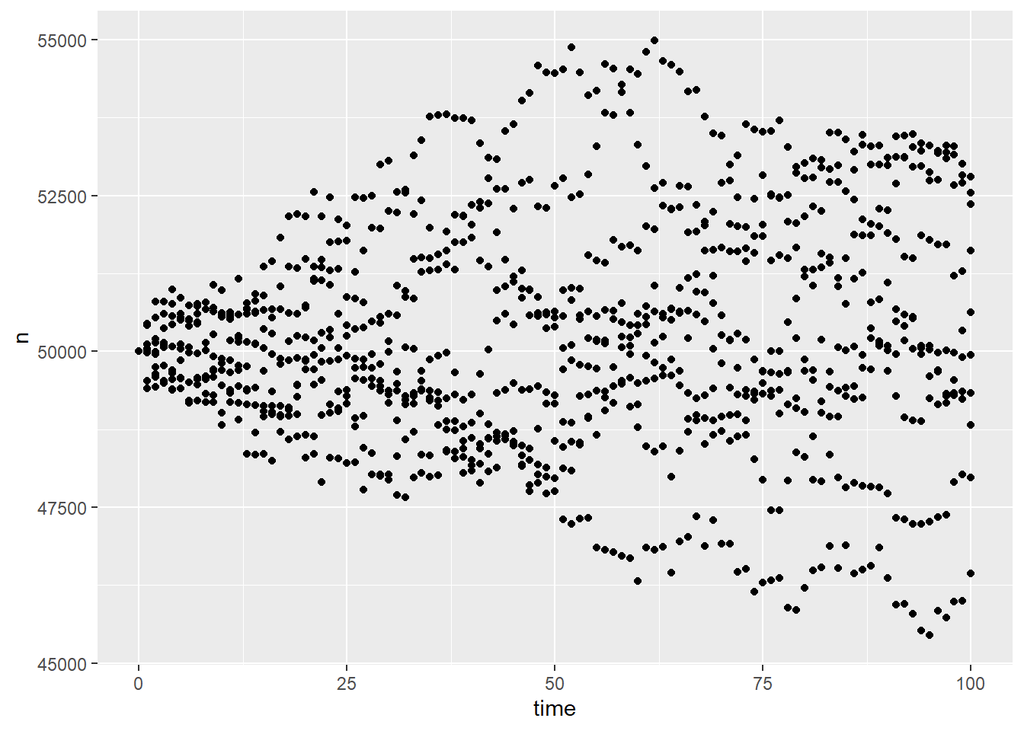

```r
ggplot(tpop, aes(x = time, y = n))+
  geom_point()
```

Show color based on trial number and line connecting dots

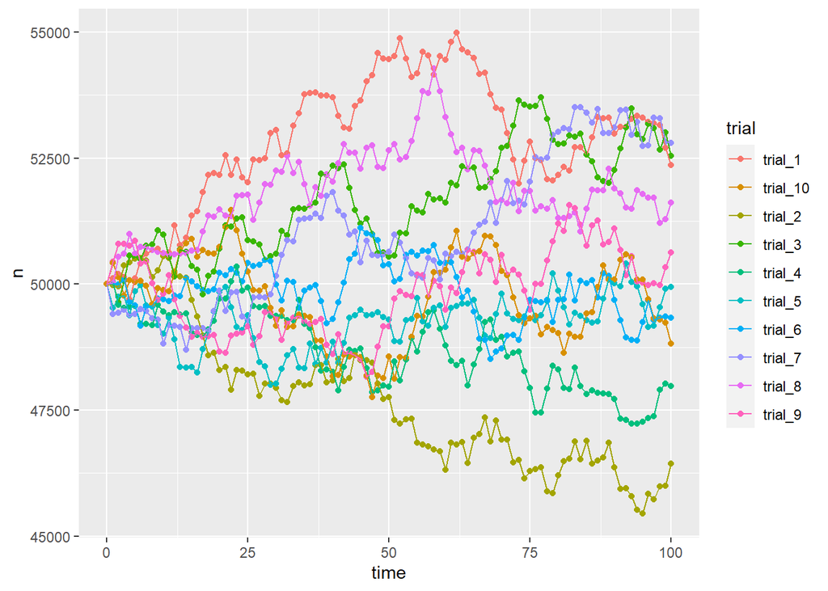

```r
ggplot(tpop, aes(x = time, y = n, color = trial))+
  geom_point()+
  geom_line()
```

Change labels and style of plot

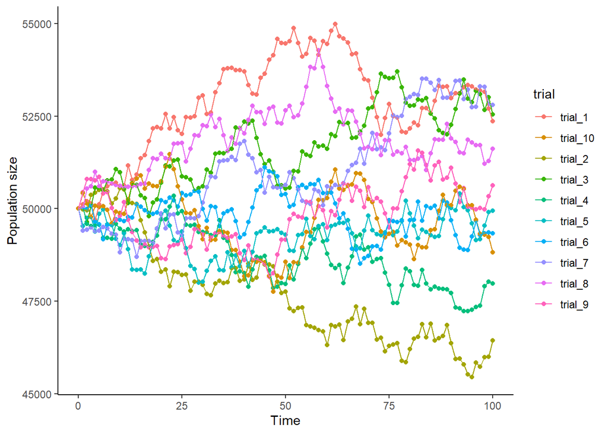

```r
ggplot(tpop, aes(x = time, y = n, color = trial))+
  geom_point()+
  geom_line()+
  labs(x = 'Time', y = 'Population size')+
  theme_classic()
```

Modify the size of axis label text and legend position

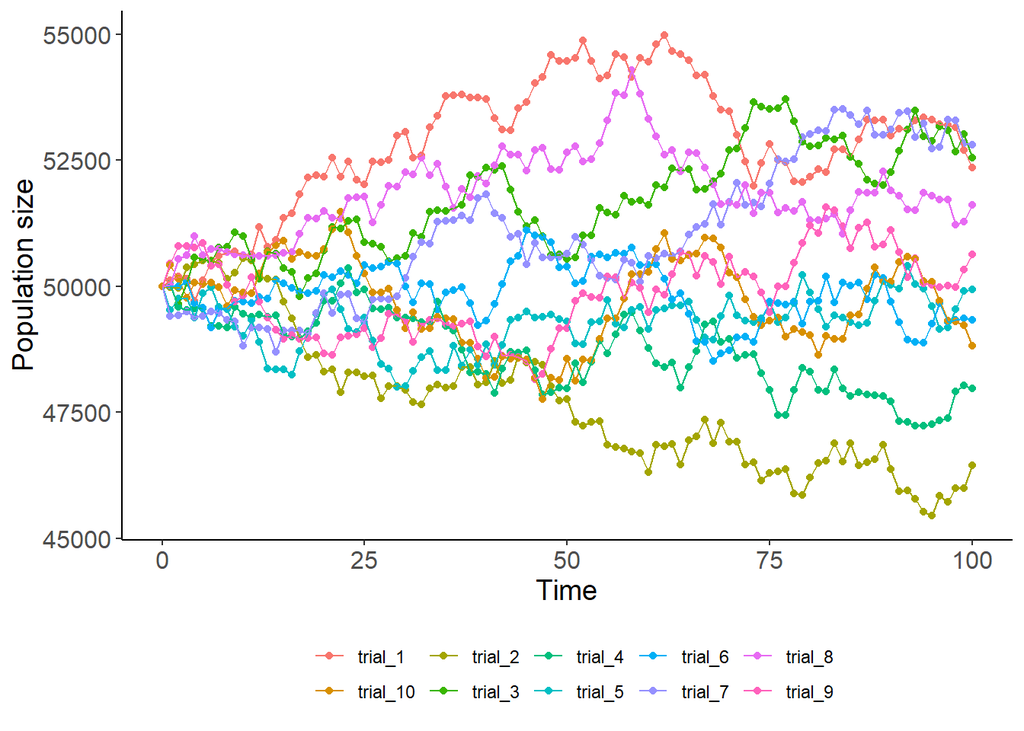

```r
ggplot(tpop, aes(x = time, y = n, color = trial))+
  geom_point()+
  geom_line()+
  labs(x = 'Time', y = 'Population size')+
  theme_classic()+
  theme(axis.title = element_text(size = 14),
        axis.text = element_text(size = 12),
        legend.position = 'bottom',
        legend.title = element_blank())
```

Modify the range of time on x axis

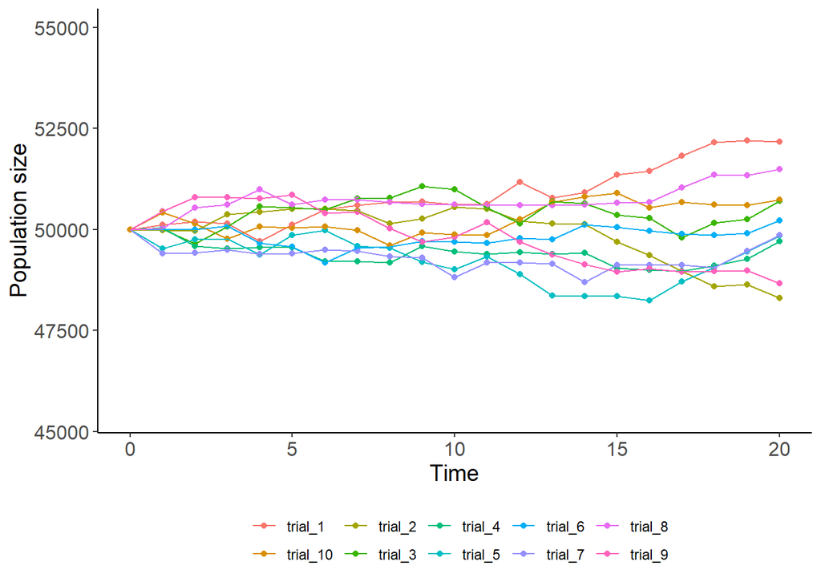

```r
ggplot(tpop, aes(x = time, y = n, color = trial))+
  geom_point()+
  geom_line()+
  scale_x_continuous(limits = c(0,20))+
  labs(x = 'Time', y = 'Population size')+
  theme_classic()+
  theme(axis.title = element_text(size = 14),
        axis.text = element_text(size = 12),
        legend.position = 'bottom',
        legend.title = element_blank())
```

Split each trial into own grid

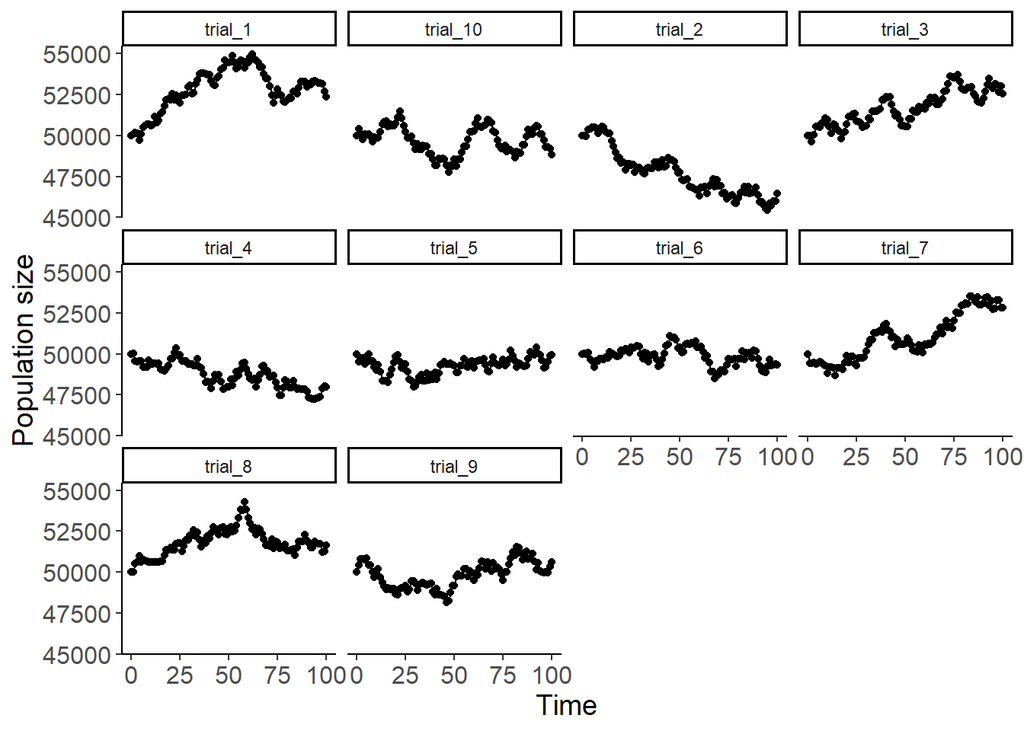

```r
ggplot(tpop, aes(x = time, y = n))+
  geom_point()+
  geom_line()+
  labs(x = 'Time', y = 'Population size')+
  facet_wrap(~trial)+
  theme_classic()+
  theme(axis.title = element_text(size = 14),
        axis.text = element_text(size = 12),
        legend.position = 'bottom',
        legend.title = element_blank())
```

Modify the label and size of strip text

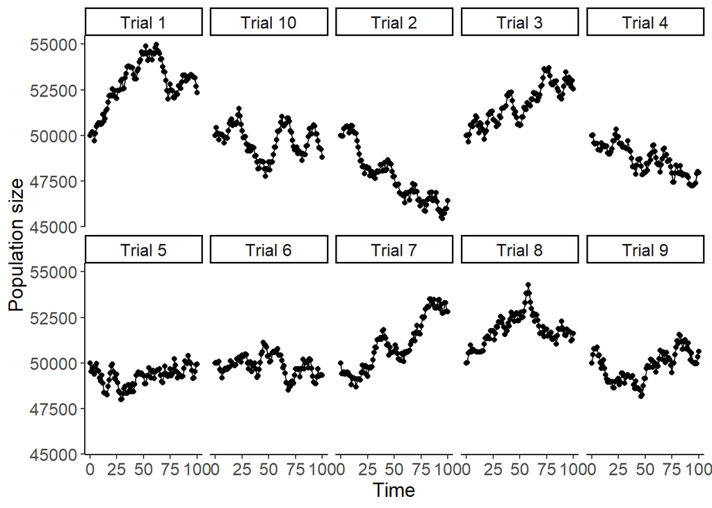

```r
labels = c('trial_1' = 'Trial 1',
          'trial_2' = 'Trial 2',
          'trial_3' = 'Trial 3',
          'trial_4' = 'Trial 4',
          'trial_5' = 'Trial 5',
          'trial_6' = 'Trial 6',
          'trial_7' = 'Trial 7',
          'trial_8' = 'Trial 8',
          'trial_9' = 'Trial 9',
          'trial_10' = 'Trial 10')

ggplot(tpop, aes(x = time, y = n))+
  geom_point()+
  geom_line()+
  labs(x = 'Time', y = 'Population size')+
  facet_wrap(~trial, nrow = 2, labeller = as_labeller(labels))+
  theme_classic()+
  theme(axis.title = element_text(size = 14),
        axis.text = element_text(size = 12),
        legend.position = 'bottom',
        legend.title = element_blank(),
        strip.text = element_text(size = 12))
```

Remake figure with the mean and min and max values from the multiple trials

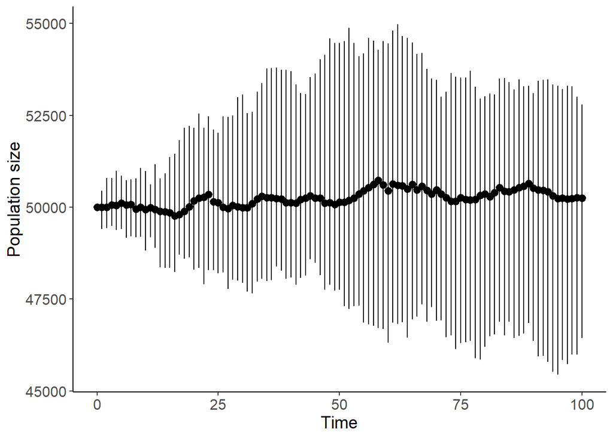

```r
ggplot(tpop, aes(x = time, y = n))+
  geom_pointrange(stat = "summary",
                  fun.min = 'min',
                  fun.max = 'max',
                  fun = 'mean')+
  labs(x = 'Time', y = 'Population size')+
  theme_classic()+
  theme(axis.title = element_text(size = 14),
        axis.text = element_text(size = 12))
```

Make box plot of change in population size based on type of year

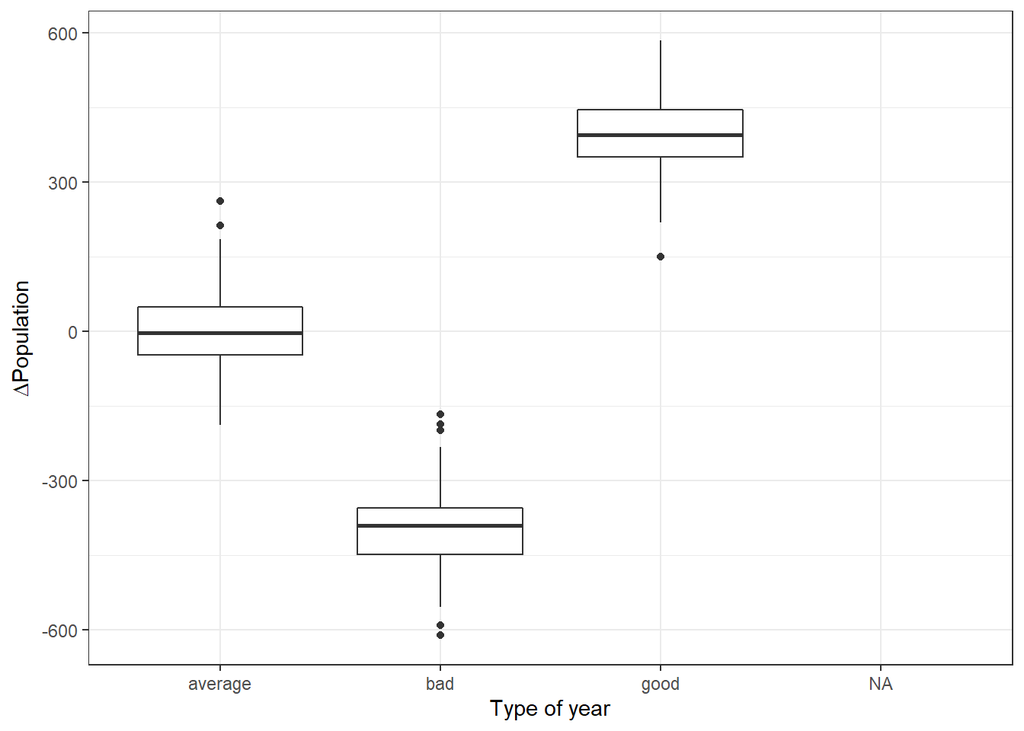

```r
ggplot(tpop, aes(x = year, y = change))+
  geom_boxplot()+
  labs(x = 'Type of year', y = expression(Delta*'Population'))+
  theme_bw()
```

Remove `NA` and add color to plot

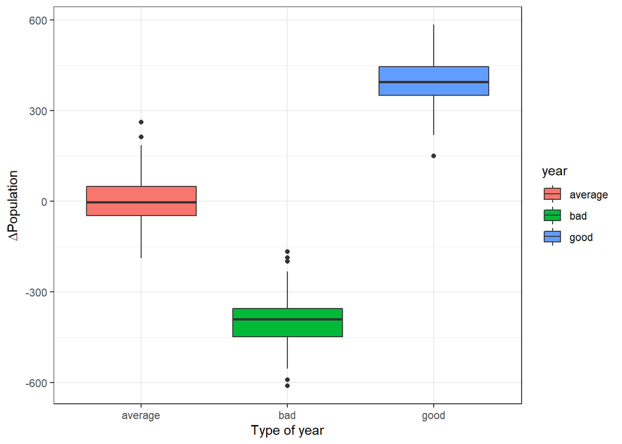

```r
ggplot(tpop %>% drop_na, aes(x = year, y = change, fill = year))+
  geom_boxplot()+
  labs(x = 'Type of year', y = expression(Delta*'Population'))+
  theme_bw()
```

Change order of x axis and color of plot. Colors can be both hex code or from names that R has. A help website for picking colors is [here](https://rstudio-pubs-static.s3.amazonaws.com/3486_79191ad32cf74955b4502b8530aad627.html).

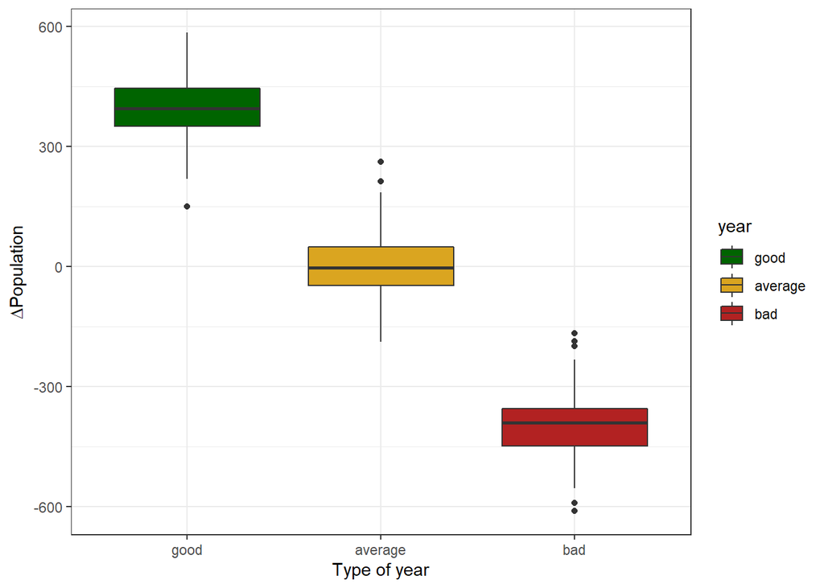

```r
tpop = tpop %>%
  mutate(year = factor(year, levels = c('good', 'average', 'bad')))%>%
  drop_na

colors = c('good' = 'darkgreen',
           'average' = 'goldenrod',
           'bad' = 'firebrick')

ggplot(tpop, aes(x = year, y = change, fill = year))+
  geom_boxplot()+
  labs(x = 'Type of year', y = expression(Delta*'Population'))+
  scale_fill_manual(values = colors)+
  theme_bw()
```

Modify the labels and remove the legend

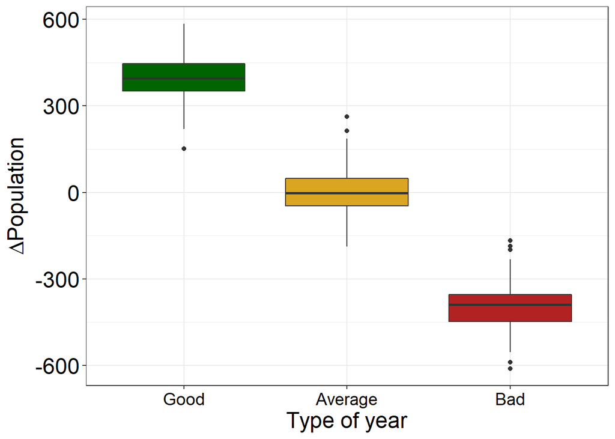

```r
ggplot(tpop, aes(x = year, y = change, fill = year))+
  geom_boxplot()+
  labs(x = 'Type of year', y = expression(Delta*'Population'))+
  scale_x_discrete(labels = c('Good', 'Average', 'Bad'))+
  scale_fill_manual(values = colors)+
  theme_bw()+
  theme(axis.title = element_text(size = 18),
        axis.text.y = element_text(size = 18, colour = "black"),
        axis.text.x = element_text(size = 14, colour = "black"),
        legend.position = 'none',
        legend.title = element_blank(),
        strip.text.x = element_text(size = 18),
        legend.text = element_text(size = 12))
```